# Assignment 7 (Clustering) Q1.Airlines

## Q1. Perform clustering (hierarchical,K means clustering and DBSCAN) for the airlines data to obtain optimum number of clusters. Draw the inferences from the clusters obtained.

## Data Description:

## The file EastWestAirlinescontains information on passengers who belong to an airline’s frequent flier program. For each passenger the data include information on their mileage history and on different ways they accrued or spent miles in the last year. The goal is to try to identify clusters of passengers that have similar characteristics for the purpose of targeting different segments for different types of mileage offers

## Balance--Number of miles eligible for award travel

## Qual_mile--Number of miles counted as qualifying for Topflight status

## cc1_miles -- Number of miles earned with freq. flyer credit card in the past 12 months:

## cc2_miles -- Number of miles earned with Rewards credit card in the past 12 months:

## cc3_miles -- Number of miles earned with Small Business credit card in the past 12 months:

## 1 = under 5,000

## 2 = 5,000 - 10,000

## 3 = 10,001 - 25,000

## 4 = 25,001 - 50,000

## 5 = over 50,000

## Bonus_miles--Number of miles earned from non-flight bonus transactions in the past 12 months

## Bonus_trans--Number of non-flight bonus transactions in the past 12 months

## Flight_miles_12mo--Number of flight miles in the past 12 months

## Flight_trans_12--Number of flight transactions in the past 12 months

## Days_since_enrolled--Number of days since enrolled in flier program

## Award--whether that person had award flight (free flight) or not

```python
# Importing Required Libraries
import pandas as pd
import numpy as np
import seaborn as sns
import matplotlib.pyplot as plt
import scipy.cluster.hierarchy as sch
from sklearn.cluster import AgglomerativeClustering
from sklearn.preprocessing import normalize
```

```python
# Importing Dataset
airline_df=pd.read_csv('EastWestAirlines.csv')
airline_df
```

|  | ID# | Balance | Qual_miles | cc1_miles | cc2_miles | cc3_miles | Bonus_miles | Bonus_trans | Flight_miles_12mo | Flight_trans_12 | Days_since_enroll | Award? |
| --- | --- | --- | --- | --- | --- | --- | --- | --- | --- | --- | --- | --- |
| 0 | 1 | 28143 | 0 | 1 | 1 | 1 | 174 | 1 | 0 | 0 | 7000 | 0 |
| 1 | 2 | 19244 | 0 | 1 | 1 | 1 | 215 | 2 | 0 | 0 | 6968 | 0 |
| 2 | 3 | 41354 | 0 | 1 | 1 | 1 | 4123 | 4 | 0 | 0 | 7034 | 0 |
| 3 | 4 | 14776 | 0 | 1 | 1 | 1 | 500 | 1 | 0 | 0 | 6952 | 0 |
| 4 | 5 | 97752 | 0 | 4 | 1 | 1 | 43300 | 26 | 2077 | 4 | 6935 | 1 |
| 5 | 6 | 16420 | 0 | 1 | 1 | 1 | 0 | 0 | 0 | 0 | 6942 | 0 |
| 6 | 7 | 84914 | 0 | 3 | 1 | 1 | 27482 | 25 | 0 | 0 | 6994 | 0 |
| 7 | 8 | 20856 | 0 | 1 | 1 | 1 | 5250 | 4 | 250 | 1 | 6938 | 1 |
| 8 | 9 | 443003 | 0 | 3 | 2 | 1 | 1753 | 43 | 3850 | 12 | 6948 | 1 |
| 9 | 10 | 104860 | 0 | 3 | 1 | 1 | 28426 | 28 | 1150 | 3 | 6931 | 1 |
| 10 | 11 | 40091 | 0 | 2 | 1 | 1 | 7278 | 10 | 0 | 0 | 6959 | 0 |
| 11 | 12 | 96522 | 0 | 5 | 1 | 1 | 61105 | 19 | 0 | 0 | 6924 | 1 |
| 12 | 13 | 43382 | 0 | 2 | 1 | 1 | 11150 | 20 | 0 | 0 | 6924 | 0 |
| 13 | 14 | 43097 | 0 | 1 | 1 | 1 | 3258 | 6 | 0 | 0 | 6918 | 0 |
| 14 | 15 | 17648 | 0 | 1 | 1 | 1 | 0 | 0 | 0 | 0 | 6912 | 0 |
| 15 | 16 | 28495 | 0 | 4 | 1 | 1 | 49442 | 15 | 0 | 0 | 6912 | 1 |
| 16 | 17 | 51890 | 0 | 4 | 1 | 1 | 48963 | 16 | 0 | 0 | 6910 | 1 |
| 17 | 18 | 13958 | 0 | 1 | 1 | 1 | 4291 | 5 | 0 | 0 | 6905 | 1 |
| 18 | 19 | 91473 | 0 | 3 | 1 | 1 | 27408 | 17 | 0 | 0 | 6903 | 1 |
| 19 | 20 | 23354 | 0 | 3 | 1 | 1 | 10447 | 5 | 0 | 0 | 6896 | 1 |
| 20 | 21 | 120576 | 0 | 5 | 1 | 1 | 58831 | 23 | 250 | 2 | 6896 | 1 |
| 21 | 22 | 185681 | 2024 | 1 | 1 | 1 | 13300 | 16 | 1800 | 9 | 6896 | 1 |
| 22 | 23 | 20584 | 0 | 1 | 1 | 1 | 3450 | 11 | 3450 | 11 | 6884 | 0 |
| 23 | 24 | 66275 | 0 | 1 | 1 | 1 | 2533 | 11 | 150 | 1 | 6884 | 0 |
| 24 | 25 | 205651 | 500 | 1 | 1 | 1 | 4025 | 21 | 700 | 4 | 7932 | 0 |
| 25 | 26 | 20726 | 0 | 1 | 1 | 1 | 1375 | 4 | 0 | 0 | 7924 | 0 |
| 26 | 27 | 18521 | 0 | 1 | 1 | 1 | 1227 | 2 | 1227 | 2 | 7917 | 0 |
| 27 | 28 | 8828 | 0 | 1 | 1 | 1 | 0 | 0 | 0 | 0 | 7914 | 0 |
| 28 | 29 | 59763 | 0 | 3 | 1 | 1 | 33772 | 20 | 100 | 1 | 7907 | 1 |
| 29 | 30 | 19221 | 0 | 1 | 1 | 1 | 4655 | 8 | 500 | 1 | 7896 | 1 |
| ... | ... | ... | ... | ... | ... | ... | ... | ... | ... | ... | ... | ... |
| 3969 | 3992 | 12532 | 0 | 1 | 1 | 1 | 2069 | 9 | 0 | 0 | 1445 | 0 |
| 3970 | 3993 | 52584 | 0 | 1 | 1 | 1 | 2500 | 1 | 0 | 0 | 1439 | 0 |
| 3971 | 3994 | 20954 | 0 | 1 | 1 | 1 | 375 | 3 | 0 | 0 | 1438 | 0 |
| 3972 | 3995 | 35185 | 0 | 2 | 1 | 1 | 5957 | 7 | 0 | 0 | 1439 | 0 |
| 3973 | 3996 | 72297 | 0 | 3 | 1 | 1 | 16241 | 16 | 0 | 0 | 1587 | 1 |
| 3974 | 3997 | 58387 | 0 | 3 | 1 | 1 | 14581 | 39 | 0 | 0 | 1435 | 0 |
| 3975 | 3998 | 9128 | 0 | 1 | 1 | 1 | 0 | 0 | 0 | 0 | 1424 | 0 |
| 3976 | 3999 | 37520 | 0 | 1 | 1 | 1 | 19924 | 6 | 0 | 0 | 1432 | 0 |
| 3977 | 4000 | 9399 | 0 | 1 | 1 | 1 | 2125 | 10 | 0 | 0 | 1430 | 0 |
| 3978 | 4001 | 10071 | 0 | 2 | 1 | 1 | 27701 | 16 | 0 | 0 | 1421 | 1 |
| 3979 | 4002 | 57793 | 0 | 3 | 1 | 1 | 20959 | 15 | 1198 | 3 | 1424 | 1 |
| 3980 | 4003 | 28867 | 0 | 3 | 1 | 1 | 19169 | 28 | 0 | 0 | 1425 | 0 |
| 3981 | 4004 | 1010 | 0 | 1 | 1 | 1 | 0 | 0 | 0 | 0 | 1423 | 0 |
| 3982 | 4005 | 11463 | 0 | 1 | 1 | 1 | 339 | 4 | 0 | 0 | 1425 | 0 |
| 3983 | 4006 | 26173 | 0 | 1 | 1 | 1 | 305 | 1 | 0 | 0 | 1418 | 0 |
| 3984 | 4007 | 404 | 0 | 1 | 1 | 1 | 550 | 3 | 0 | 0 | 1418 | 0 |
| 3985 | 4008 | 59017 | 0 | 4 | 1 | 1 | 34746 | 25 | 0 | 0 | 1418 | 0 |
| 3986 | 4009 | 34235 | 0 | 1 | 1 | 1 | 18910 | 7 | 250 | 1 | 1415 | 0 |
| 3987 | 4010 | 11933 | 0 | 1 | 1 | 1 | 249 | 3 | 79 | 1 | 1412 | 1 |
| 3988 | 4011 | 5000 | 0 | 1 | 1 | 1 | 2125 | 3 | 0 | 0 | 1412 | 0 |
| 3989 | 4012 | 2622 | 0 | 1 | 1 | 1 | 1625 | 6 | 0 | 0 | 1404 | 1 |
| 3990 | 4013 | 11310 | 0 | 1 | 1 | 1 | 5021 | 2 | 0 | 0 | 1409 | 0 |
| 3991 | 4014 | 39142 | 0 | 3 | 1 | 1 | 14981 | 28 | 0 | 0 | 1408 | 0 |
| 3992 | 4015 | 11181 | 0 | 1 | 1 | 1 | 929 | 12 | 0 | 0 | 1407 | 0 |
| 3993 | 4016 | 3974 | 0 | 1 | 1 | 1 | 365 | 3 | 0 | 0 | 1397 | 0 |
| 3994 | 4017 | 18476 | 0 | 1 | 1 | 1 | 8525 | 4 | 200 | 1 | 1403 | 1 |
| 3995 | 4018 | 64385 | 0 | 1 | 1 | 1 | 981 | 5 | 0 | 0 | 1395 | 1 |
| 3996 | 4019 | 73597 | 0 | 3 | 1 | 1 | 25447 | 8 | 0 | 0 | 1402 | 1 |
| 3997 | 4020 | 54899 | 0 | 1 | 1 | 1 | 500 | 1 | 500 | 1 | 1401 | 0 |
| 3998 | 4021 | 3016 | 0 | 1 | 1 | 1 | 0 | 0 | 0 | 0 | 1398 | 0 |

3999 rows × 12 columns

```python
airline_df.info()
```

```
<class 'pandas.core.frame.DataFrame'>
RangeIndex: 3999 entries, 0 to 3998
Data columns (total 12 columns):
ID#                  3999 non-null int64
Balance              3999 non-null int64
Qual_miles           3999 non-null int64
cc1_miles            3999 non-null int64
cc2_miles            3999 non-null int64
cc3_miles            3999 non-null int64
Bonus_miles          3999 non-null int64
Bonus_trans          3999 non-null int64
Flight_miles_12mo    3999 non-null int64
Flight_trans_12      3999 non-null int64
Days_since_enroll    3999 non-null int64
Award?               3999 non-null int64
dtypes: int64(12)
memory usage: 375.0 KB
```

```python
airline_df.isnull().sum()
```

```
ID#                  0
Balance              0
Qual_miles           0
cc1_miles            0
cc2_miles            0
cc3_miles            0
Bonus_miles          0
Bonus_trans          0
Flight_miles_12mo    0
Flight_trans_12      0
Days_since_enroll    0
Award?               0
dtype: int64
```

```
Correlation :
                         ID#   Balance  Qual_miles  cc1_miles  cc2_miles  \
ID#                1.000000 -0.243737   -0.019374  -0.224465   0.020291
Balance           -0.243737  1.000000    0.108722   0.338344  -0.008804
Qual_miles        -0.019374  0.108722    1.000000   0.007931  -0.013923
cc1_miles         -0.224465  0.338344    0.007931   1.000000  -0.068223
cc2_miles          0.020291 -0.008804   -0.013923  -0.068223   1.000000
cc3_miles         -0.014707  0.035243   -0.007779   0.060555  -0.006166
Bonus_miles       -0.203012  0.403487    0.031021   0.825200  -0.003969
Bonus_trans       -0.146915  0.324935    0.050725   0.608943   0.064399
Flight_miles_12mo -0.031013  0.217551    0.126774   0.037370   0.010598
Flight_trans_12   -0.052096  0.255700    0.144004   0.041333   0.028284
Days_since_enroll -0.964988  0.263129    0.017312   0.230849  -0.005807
Award?            -0.177901  0.178494    0.095256   0.335457   0.005332

                   cc3_miles  Bonus_miles  Bonus_trans  Flight_miles_12mo  \
ID#                -0.014707    -0.203012    -0.146915          -0.031013
Balance             0.035243     0.403487     0.324935           0.217551
Qual_miles         -0.007779     0.031021     0.050725           0.126774
cc1_miles           0.060555     0.825200     0.608943           0.037370
cc2_miles          -0.006166    -0.003969     0.064399           0.010598
cc3_miles           1.000000     0.204134     0.097313          -0.001777
Bonus_miles         0.204134     1.000000     0.603180           0.183536
Bonus_trans         0.097313     0.603180     1.000000           0.377216
Flight_miles_12mo  -0.001777     0.183536     0.377216           1.000000
Flight_trans_12    -0.001117     0.185261     0.432364           0.869193
Days_since_enroll   0.010832     0.210397     0.161262           0.037271
Award?              0.023484     0.373506     0.333893           0.217715

                   Flight_trans_12  Days_since_enroll    Award?
ID#                      -0.052096          -0.964988 -0.177901
Balance                   0.255700           0.263129  0.178494
Qual_miles                0.144004           0.017312  0.095256
cc1_miles                 0.041333           0.230849  0.335457
cc2_miles                 0.028284          -0.005807  0.005332
cc3_miles                -0.001117           0.010832  0.023484
Bonus_miles               0.185261           0.210397  0.373506
Bonus_trans               0.432364           0.161262  0.333893
Flight_miles_12mo         0.869193           0.037271  0.217715
Flight_trans_12           1.000000           0.059260  0.247909
Days_since_enroll         0.059260           1.000000  0.188121
Award?                    0.247909           0.188121  1.000000
```

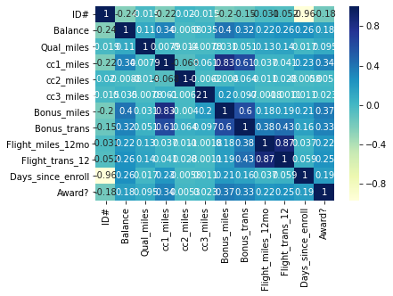

```python
airline_corr = airline_df.corr()
print('Correlation : \n',airline_corr)
sns.heatmap(airline_corr,cmap='YlGnBu',annot=True)
```

```python
airline_df1=airline_df.drop(['ID#'],axis=1)
airline_df1
```

|  | Balance | Qual_miles | cc1_miles | cc2_miles | cc3_miles | Bonus_miles | Bonus_trans | Flight_miles_12mo | Flight_trans_12 | Days_since_enroll | Award? |
| --- | --- | --- | --- | --- | --- | --- | --- | --- | --- | --- | --- |
| 0 | 28143 | 0 | 1 | 1 | 1 | 174 | 1 | 0 | 0 | 7000 | 0 |
| 1 | 19244 | 0 | 1 | 1 | 1 | 215 | 2 | 0 | 0 | 6968 | 0 |
| 2 | 41354 | 0 | 1 | 1 | 1 | 4123 | 4 | 0 | 0 | 7034 | 0 |
| 3 | 14776 | 0 | 1 | 1 | 1 | 500 | 1 | 0 | 0 | 6952 | 0 |
| 4 | 97752 | 0 | 4 | 1 | 1 | 43300 | 26 | 2077 | 4 | 6935 | 1 |
| 5 | 16420 | 0 | 1 | 1 | 1 | 0 | 0 | 0 | 0 | 6942 | 0 |
| 6 | 84914 | 0 | 3 | 1 | 1 | 27482 | 25 | 0 | 0 | 6994 | 0 |
| 7 | 20856 | 0 | 1 | 1 | 1 | 5250 | 4 | 250 | 1 | 6938 | 1 |
| 8 | 443003 | 0 | 3 | 2 | 1 | 1753 | 43 | 3850 | 12 | 6948 | 1 |
| 9 | 104860 | 0 | 3 | 1 | 1 | 28426 | 28 | 1150 | 3 | 6931 | 1 |
| 10 | 40091 | 0 | 2 | 1 | 1 | 7278 | 10 | 0 | 0 | 6959 | 0 |
| 11 | 96522 | 0 | 5 | 1 | 1 | 61105 | 19 | 0 | 0 | 6924 | 1 |
| 12 | 43382 | 0 | 2 | 1 | 1 | 11150 | 20 | 0 | 0 | 6924 | 0 |
| 13 | 43097 | 0 | 1 | 1 | 1 | 3258 | 6 | 0 | 0 | 6918 | 0 |
| 14 | 17648 | 0 | 1 | 1 | 1 | 0 | 0 | 0 | 0 | 6912 | 0 |
| 15 | 28495 | 0 | 4 | 1 | 1 | 49442 | 15 | 0 | 0 | 6912 | 1 |
| 16 | 51890 | 0 | 4 | 1 | 1 | 48963 | 16 | 0 | 0 | 6910 | 1 |
| 17 | 13958 | 0 | 1 | 1 | 1 | 4291 | 5 | 0 | 0 | 6905 | 1 |
| 18 | 91473 | 0 | 3 | 1 | 1 | 27408 | 17 | 0 | 0 | 6903 | 1 |
| 19 | 23354 | 0 | 3 | 1 | 1 | 10447 | 5 | 0 | 0 | 6896 | 1 |
| 20 | 120576 | 0 | 5 | 1 | 1 | 58831 | 23 | 250 | 2 | 6896 | 1 |
| 21 | 185681 | 2024 | 1 | 1 | 1 | 13300 | 16 | 1800 | 9 | 6896 | 1 |
| 22 | 20584 | 0 | 1 | 1 | 1 | 3450 | 11 | 3450 | 11 | 6884 | 0 |
| 23 | 66275 | 0 | 1 | 1 | 1 | 2533 | 11 | 150 | 1 | 6884 | 0 |
| 24 | 205651 | 500 | 1 | 1 | 1 | 4025 | 21 | 700 | 4 | 7932 | 0 |
| 25 | 20726 | 0 | 1 | 1 | 1 | 1375 | 4 | 0 | 0 | 7924 | 0 |
| 26 | 18521 | 0 | 1 | 1 | 1 | 1227 | 2 | 1227 | 2 | 7917 | 0 |
| 27 | 8828 | 0 | 1 | 1 | 1 | 0 | 0 | 0 | 0 | 7914 | 0 |
| 28 | 59763 | 0 | 3 | 1 | 1 | 33772 | 20 | 100 | 1 | 7907 | 1 |
| 29 | 19221 | 0 | 1 | 1 | 1 | 4655 | 8 | 500 | 1 | 7896 | 1 |
| ... | ... | ... | ... | ... | ... | ... | ... | ... | ... | ... | ... |
| 3969 | 12532 | 0 | 1 | 1 | 1 | 2069 | 9 | 0 | 0 | 1445 | 0 |
| 3970 | 52584 | 0 | 1 | 1 | 1 | 2500 | 1 | 0 | 0 | 1439 | 0 |
| 3971 | 20954 | 0 | 1 | 1 | 1 | 375 | 3 | 0 | 0 | 1438 | 0 |
| 3972 | 35185 | 0 | 2 | 1 | 1 | 5957 | 7 | 0 | 0 | 1439 | 0 |
| 3973 | 72297 | 0 | 3 | 1 | 1 | 16241 | 16 | 0 | 0 | 1587 | 1 |
| 3974 | 58387 | 0 | 3 | 1 | 1 | 14581 | 39 | 0 | 0 | 1435 | 0 |
| 3975 | 9128 | 0 | 1 | 1 | 1 | 0 | 0 | 0 | 0 | 1424 | 0 |
| 3976 | 37520 | 0 | 1 | 1 | 1 | 19924 | 6 | 0 | 0 | 1432 | 0 |
| 3977 | 9399 | 0 | 1 | 1 | 1 | 2125 | 10 | 0 | 0 | 1430 | 0 |
| 3978 | 10071 | 0 | 2 | 1 | 1 | 27701 | 16 | 0 | 0 | 1421 | 1 |
| 3979 | 57793 | 0 | 3 | 1 | 1 | 20959 | 15 | 1198 | 3 | 1424 | 1 |
| 3980 | 28867 | 0 | 3 | 1 | 1 | 19169 | 28 | 0 | 0 | 1425 | 0 |
| 3981 | 1010 | 0 | 1 | 1 | 1 | 0 | 0 | 0 | 0 | 1423 | 0 |
| 3982 | 11463 | 0 | 1 | 1 | 1 | 339 | 4 | 0 | 0 | 1425 | 0 |
| 3983 | 26173 | 0 | 1 | 1 | 1 | 305 | 1 | 0 | 0 | 1418 | 0 |
| 3984 | 404 | 0 | 1 | 1 | 1 | 550 | 3 | 0 | 0 | 1418 | 0 |
| 3985 | 59017 | 0 | 4 | 1 | 1 | 34746 | 25 | 0 | 0 | 1418 | 0 |
| 3986 | 34235 | 0 | 1 | 1 | 1 | 18910 | 7 | 250 | 1 | 1415 | 0 |
| 3987 | 11933 | 0 | 1 | 1 | 1 | 249 | 3 | 79 | 1 | 1412 | 1 |
| 3988 | 5000 | 0 | 1 | 1 | 1 | 2125 | 3 | 0 | 0 | 1412 | 0 |
| 3989 | 2622 | 0 | 1 | 1 | 1 | 1625 | 6 | 0 | 0 | 1404 | 1 |
| 3990 | 11310 | 0 | 1 | 1 | 1 | 5021 | 2 | 0 | 0 | 1409 | 0 |
| 3991 | 39142 | 0 | 3 | 1 | 1 | 14981 | 28 | 0 | 0 | 1408 | 0 |
| 3992 | 11181 | 0 | 1 | 1 | 1 | 929 | 12 | 0 | 0 | 1407 | 0 |
| 3993 | 3974 | 0 | 1 | 1 | 1 | 365 | 3 | 0 | 0 | 1397 | 0 |
| 3994 | 18476 | 0 | 1 | 1 | 1 | 8525 | 4 | 200 | 1 | 1403 | 1 |
| 3995 | 64385 | 0 | 1 | 1 | 1 | 981 | 5 | 0 | 0 | 1395 | 1 |
| 3996 | 73597 | 0 | 3 | 1 | 1 | 25447 | 8 | 0 | 0 | 1402 | 1 |
| 3997 | 54899 | 0 | 1 | 1 | 1 | 500 | 1 | 500 | 1 | 1401 | 0 |
| 3998 | 3016 | 0 | 1 | 1 | 1 | 0 | 0 | 0 | 0 | 1398 | 0 |

3999 rows × 11 columns

```python
# Normalizing Heterogenous Numerical Data
airline_norm=pd.DataFrame(normalize(airline_df1),columns=airline_df1.columns)
airline_norm
```

|  | Balance | Qual_miles | cc1_miles | cc2_miles | cc3_miles | Bonus_miles | Bonus_trans | Flight_miles_12mo | Flight_trans_12 | Days_since_enroll | Award? |
| --- | --- | --- | --- | --- | --- | --- | --- | --- | --- | --- | --- |
| 0 | 0.970414 | 0.000000 | 0.000034 | 0.000034 | 0.000034 | 0.006000 | 0.000034 | 0.000000 | 0.000000 | 0.241371 | 0.000000 |
| 1 | 0.940209 | 0.000000 | 0.000049 | 0.000049 | 0.000049 | 0.010504 | 0.000098 | 0.000000 | 0.000000 | 0.340437 | 0.000000 |
| 2 | 0.981113 | 0.000000 | 0.000024 | 0.000024 | 0.000024 | 0.097817 | 0.000095 | 0.000000 | 0.000000 | 0.166880 | 0.000000 |
| 3 | 0.904428 | 0.000000 | 0.000061 | 0.000061 | 0.000061 | 0.030605 | 0.000061 | 0.000000 | 0.000000 | 0.425527 | 0.000000 |
| 4 | 0.912226 | 0.000000 | 0.000037 | 0.000009 | 0.000009 | 0.404078 | 0.000243 | 0.019383 | 0.000037 | 0.064718 | 0.000009 |
| 5 | 0.921066 | 0.000000 | 0.000056 | 0.000056 | 0.000056 | 0.000000 | 0.000000 | 0.000000 | 0.000000 | 0.389406 | 0.000000 |
| 6 | 0.948504 | 0.000000 | 0.000034 | 0.000011 | 0.000011 | 0.306979 | 0.000279 | 0.000000 | 0.000000 | 0.078124 | 0.000000 |
| 7 | 0.922856 | 0.000000 | 0.000044 | 0.000044 | 0.000044 | 0.232307 | 0.000177 | 0.011062 | 0.000044 | 0.306999 | 0.000044 |
| 8 | 0.999831 | 0.000000 | 0.000007 | 0.000005 | 0.000002 | 0.003956 | 0.000097 | 0.008689 | 0.000027 | 0.015681 | 0.000002 |
| 9 | 0.963153 | 0.000000 | 0.000028 | 0.000009 | 0.000009 | 0.261097 | 0.000257 | 0.010563 | 0.000028 | 0.063662 | 0.000009 |
| 10 | 0.969875 | 0.000000 | 0.000048 | 0.000024 | 0.000024 | 0.176068 | 0.000242 | 0.000000 | 0.000000 | 0.168351 | 0.000000 |
| 11 | 0.843373 | 0.000000 | 0.000044 | 0.000009 | 0.000009 | 0.533912 | 0.000166 | 0.000000 | 0.000000 | 0.060499 | 0.000009 |
| 12 | 0.957153 | 0.000000 | 0.000044 | 0.000022 | 0.000022 | 0.246007 | 0.000441 | 0.000000 | 0.000000 | 0.152767 | 0.000000 |
| 13 | 0.984621 | 0.000000 | 0.000023 | 0.000023 | 0.000023 | 0.074434 | 0.000137 | 0.000000 | 0.000000 | 0.158053 | 0.000000 |
| 14 | 0.931131 | 0.000000 | 0.000053 | 0.000053 | 0.000053 | 0.000000 | 0.000000 | 0.000000 | 0.000000 | 0.364686 | 0.000000 |
| 15 | 0.495715 | 0.000000 | 0.000070 | 0.000017 | 0.000017 | 0.860121 | 0.000261 | 0.000000 | 0.000000 | 0.120245 | 0.000017 |
| 16 | 0.723935 | 0.000000 | 0.000056 | 0.000014 | 0.000014 | 0.683099 | 0.000223 | 0.000000 | 0.000000 | 0.096404 | 0.000014 |
| 17 | 0.864115 | 0.000000 | 0.000062 | 0.000062 | 0.000062 | 0.265648 | 0.000310 | 0.000000 | 0.000000 | 0.427476 | 0.000062 |
| 18 | 0.955431 | 0.000000 | 0.000031 | 0.000010 | 0.000010 | 0.286275 | 0.000178 | 0.000000 | 0.000000 | 0.072101 | 0.000010 |
| 19 | 0.881375 | 0.000000 | 0.000113 | 0.000038 | 0.000038 | 0.394267 | 0.000189 | 0.000000 | 0.000000 | 0.260253 | 0.000038 |
| 20 | 0.897543 | 0.000000 | 0.000037 | 0.000007 | 0.000007 | 0.437926 | 0.000171 | 0.001861 | 0.000015 | 0.051332 | 0.000007 |
| 21 | 0.996655 | 0.010864 | 0.000005 | 0.000005 | 0.000005 | 0.071389 | 0.000086 | 0.009662 | 0.000048 | 0.037015 | 0.000005 |
| 22 | 0.925279 | 0.000000 | 0.000045 | 0.000045 | 0.000045 | 0.155082 | 0.000494 | 0.155082 | 0.000494 | 0.309445 | 0.000000 |
| 23 | 0.993928 | 0.000000 | 0.000015 | 0.000015 | 0.000015 | 0.037987 | 0.000165 | 0.002250 | 0.000015 | 0.103240 | 0.000000 |
| 24 | 0.999057 | 0.002429 | 0.000005 | 0.000005 | 0.000005 | 0.019554 | 0.000102 | 0.003401 | 0.000019 | 0.038534 | 0.000000 |
| 25 | 0.932273 | 0.000000 | 0.000045 | 0.000045 | 0.000045 | 0.061849 | 0.000180 | 0.000000 | 0.000000 | 0.356428 | 0.000000 |
| 26 | 0.916121 | 0.000000 | 0.000049 | 0.000049 | 0.000049 | 0.060692 | 0.000099 | 0.060692 | 0.000099 | 0.391606 | 0.000000 |
| 27 | 0.744601 | 0.000000 | 0.000084 | 0.000084 | 0.000084 | 0.000000 | 0.000000 | 0.000000 | 0.000000 | 0.667510 | 0.000000 |
| 28 | 0.864887 | 0.000000 | 0.000043 | 0.000014 | 0.000014 | 0.488747 | 0.000289 | 0.001447 | 0.000014 | 0.114430 | 0.000014 |
| 29 | 0.902372 | 0.000000 | 0.000047 | 0.000047 | 0.000047 | 0.218539 | 0.000376 | 0.023474 | 0.000047 | 0.370695 | 0.000047 |
| ... | ... | ... | ... | ... | ... | ... | ... | ... | ... | ... | ... |
| 3969 | 0.980320 | 0.000000 | 0.000078 | 0.000078 | 0.000078 | 0.161848 | 0.000704 | 0.000000 | 0.000000 | 0.113036 | 0.000000 |
| 3970 | 0.998499 | 0.000000 | 0.000019 | 0.000019 | 0.000019 | 0.047472 | 0.000019 | 0.000000 | 0.000000 | 0.027325 | 0.000000 |
| 3971 | 0.997494 | 0.000000 | 0.000048 | 0.000048 | 0.000048 | 0.017852 | 0.000143 | 0.000000 | 0.000000 | 0.068455 | 0.000000 |
| 3972 | 0.985168 | 0.000000 | 0.000056 | 0.000028 | 0.000028 | 0.166794 | 0.000196 | 0.000000 | 0.000000 | 0.040292 | 0.000000 |
| 3973 | 0.975461 | 0.000000 | 0.000040 | 0.000013 | 0.000013 | 0.219130 | 0.000216 | 0.000000 | 0.000000 | 0.021412 | 0.000013 |
| 3974 | 0.969928 | 0.000000 | 0.000050 | 0.000017 | 0.000017 | 0.242220 | 0.000648 | 0.000000 | 0.000000 | 0.023838 | 0.000000 |
| 3975 | 0.988049 | 0.000000 | 0.000108 | 0.000108 | 0.000108 | 0.000000 | 0.000000 | 0.000000 | 0.000000 | 0.154139 | 0.000000 |
| 3976 | 0.882697 | 0.000000 | 0.000024 | 0.000024 | 0.000024 | 0.468733 | 0.000141 | 0.000000 | 0.000000 | 0.033689 | 0.000000 |
| 3977 | 0.964816 | 0.000000 | 0.000103 | 0.000103 | 0.000103 | 0.218133 | 0.001027 | 0.000000 | 0.000000 | 0.146791 | 0.000000 |
| 3978 | 0.341284 | 0.000000 | 0.000068 | 0.000034 | 0.000034 | 0.938726 | 0.000542 | 0.000000 | 0.000000 | 0.048155 | 0.000034 |
| 3979 | 0.939659 | 0.000000 | 0.000049 | 0.000016 | 0.000016 | 0.340773 | 0.000244 | 0.019478 | 0.000049 | 0.023153 | 0.000016 |
| 3980 | 0.832353 | 0.000000 | 0.000087 | 0.000029 | 0.000029 | 0.552720 | 0.000807 | 0.000000 | 0.000000 | 0.041089 | 0.000000 |
| 3981 | 0.578796 | 0.000000 | 0.000573 | 0.000573 | 0.000573 | 0.000000 | 0.000000 | 0.000000 | 0.000000 | 0.815472 | 0.000000 |
| 3982 | 0.991934 | 0.000000 | 0.000087 | 0.000087 | 0.000087 | 0.029335 | 0.000346 | 0.000000 | 0.000000 | 0.123310 | 0.000000 |
| 3983 | 0.998468 | 0.000000 | 0.000038 | 0.000038 | 0.000038 | 0.011635 | 0.000038 | 0.000000 | 0.000000 | 0.054095 | 0.000000 |
| 3984 | 0.256724 | 0.000000 | 0.000635 | 0.000635 | 0.000635 | 0.349500 | 0.001906 | 0.000000 | 0.000000 | 0.901076 | 0.000000 |
| 3985 | 0.861557 | 0.000000 | 0.000058 | 0.000015 | 0.000015 | 0.507238 | 0.000365 | 0.000000 | 0.000000 | 0.020701 | 0.000000 |
| 3986 | 0.874752 | 0.000000 | 0.000026 | 0.000026 | 0.000026 | 0.483177 | 0.000179 | 0.006388 | 0.000026 | 0.036155 | 0.000000 |
| 3987 | 0.992837 | 0.000000 | 0.000083 | 0.000083 | 0.000083 | 0.020717 | 0.000250 | 0.006573 | 0.000083 | 0.117480 | 0.000083 |
| 3988 | 0.890738 | 0.000000 | 0.000178 | 0.000178 | 0.000178 | 0.378564 | 0.000534 | 0.000000 | 0.000000 | 0.251544 | 0.000000 |
| 3989 | 0.773631 | 0.000000 | 0.000295 | 0.000295 | 0.000295 | 0.479462 | 0.001770 | 0.000000 | 0.000000 | 0.414255 | 0.000295 |
| 3990 | 0.908114 | 0.000000 | 0.000080 | 0.000080 | 0.000080 | 0.403151 | 0.000161 | 0.000000 | 0.000000 | 0.113133 | 0.000000 |
| 3991 | 0.933406 | 0.000000 | 0.000072 | 0.000024 | 0.000024 | 0.357247 | 0.000668 | 0.000000 | 0.000000 | 0.033576 | 0.000000 |
| 3992 | 0.988820 | 0.000000 | 0.000088 | 0.000088 | 0.000088 | 0.082158 | 0.001061 | 0.000000 | 0.000000 | 0.124432 | 0.000000 |
| 3993 | 0.939884 | 0.000000 | 0.000237 | 0.000237 | 0.000237 | 0.086326 | 0.000710 | 0.000000 | 0.000000 | 0.330402 | 0.000000 |
| 3994 | 0.905810 | 0.000000 | 0.000049 | 0.000049 | 0.000049 | 0.417949 | 0.000196 | 0.009805 | 0.000049 | 0.068784 | 0.000049 |
| 3995 | 0.999649 | 0.000000 | 0.000016 | 0.000016 | 0.000016 | 0.015231 | 0.000078 | 0.000000 | 0.000000 | 0.021659 | 0.000016 |
| 3996 | 0.944948 | 0.000000 | 0.000039 | 0.000013 | 0.000013 | 0.326726 | 0.000103 | 0.000000 | 0.000000 | 0.018001 | 0.000013 |
| 3997 | 0.999592 | 0.000000 | 0.000018 | 0.000018 | 0.000018 | 0.009104 | 0.000018 | 0.009104 | 0.000018 | 0.025509 | 0.000000 |
| 3998 | 0.907271 | 0.000000 | 0.000301 | 0.000301 | 0.000301 | 0.000000 | 0.000000 | 0.000000 | 0.000000 | 0.420546 | 0.000000 |

3999 rows × 11 columns

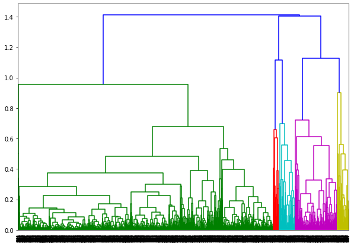

```python
# Creating Dendrograms
plt.figure(figsize=(10, 7))
dendograms_val=sch.dendrogram(sch.linkage(airline_norm,'complete'))
```

```python
# Creating Clusters
clusters=AgglomerativeClustering(n_clusters=5,affinity='euclidean',linkage='ward')
clusters
```

```
AgglomerativeClustering(affinity='euclidean', compute_full_tree='auto',
                        connectivity=None, distance_threshold=None,
                        linkage='ward', memory=None, n_clusters=5,
                        pooling_func='deprecated')
```

```python
y = pd.DataFrame(clusters.fit_predict(airline_norm),columns=['clustersid'])
y['clustersid'].value_counts()
```

```
2    1547
4    1191
3     579
1     453
0     229
Name: clustersid, dtype: int64
```

```python
# Adding Clusters to Dataset
airline_df1['clustersid'] = clusters.labels_
airline_df1
```

|  | Balance | Qual_miles | cc1_miles | cc2_miles | cc3_miles | Bonus_miles | Bonus_trans | Flight_miles_12mo | Flight_trans_12 | Days_since_enroll | Award? | clustersid |
| --- | --- | --- | --- | --- | --- | --- | --- | --- | --- | --- | --- | --- |
| 0 | 28143 | 0 | 1 | 1 | 1 | 174 | 1 | 0 | 0 | 7000 | 0 | 4 |
| 1 | 19244 | 0 | 1 | 1 | 1 | 215 | 2 | 0 | 0 | 6968 | 0 | 2 |
| 2 | 41354 | 0 | 1 | 1 | 1 | 4123 | 4 | 0 | 0 | 7034 | 0 | 2 |
| 3 | 14776 | 0 | 1 | 1 | 1 | 500 | 1 | 0 | 0 | 6952 | 0 | 2 |
| 4 | 97752 | 0 | 4 | 1 | 1 | 43300 | 26 | 2077 | 4 | 6935 | 1 | 3 |
| 5 | 16420 | 0 | 1 | 1 | 1 | 0 | 0 | 0 | 0 | 6942 | 0 | 2 |
| 6 | 84914 | 0 | 3 | 1 | 1 | 27482 | 25 | 0 | 0 | 6994 | 0 | 2 |
| 7 | 20856 | 0 | 1 | 1 | 1 | 5250 | 4 | 250 | 1 | 6938 | 1 | 2 |
| 8 | 443003 | 0 | 3 | 2 | 1 | 1753 | 43 | 3850 | 12 | 6948 | 1 | 4 |
| 9 | 104860 | 0 | 3 | 1 | 1 | 28426 | 28 | 1150 | 3 | 6931 | 1 | 2 |
| 10 | 40091 | 0 | 2 | 1 | 1 | 7278 | 10 | 0 | 0 | 6959 | 0 | 2 |
| 11 | 96522 | 0 | 5 | 1 | 1 | 61105 | 19 | 0 | 0 | 6924 | 1 | 3 |
| 12 | 43382 | 0 | 2 | 1 | 1 | 11150 | 20 | 0 | 0 | 6924 | 0 | 2 |
| 13 | 43097 | 0 | 1 | 1 | 1 | 3258 | 6 | 0 | 0 | 6918 | 0 | 2 |
| 14 | 17648 | 0 | 1 | 1 | 1 | 0 | 0 | 0 | 0 | 6912 | 0 | 2 |
| 15 | 28495 | 0 | 4 | 1 | 1 | 49442 | 15 | 0 | 0 | 6912 | 1 | 1 |
| 16 | 51890 | 0 | 4 | 1 | 1 | 48963 | 16 | 0 | 0 | 6910 | 1 | 1 |
| 17 | 13958 | 0 | 1 | 1 | 1 | 4291 | 5 | 0 | 0 | 6905 | 1 | 2 |
| 18 | 91473 | 0 | 3 | 1 | 1 | 27408 | 17 | 0 | 0 | 6903 | 1 | 2 |
| 19 | 23354 | 0 | 3 | 1 | 1 | 10447 | 5 | 0 | 0 | 6896 | 1 | 3 |
| 20 | 120576 | 0 | 5 | 1 | 1 | 58831 | 23 | 250 | 2 | 6896 | 1 | 3 |
| 21 | 185681 | 2024 | 1 | 1 | 1 | 13300 | 16 | 1800 | 9 | 6896 | 1 | 4 |
| 22 | 20584 | 0 | 1 | 1 | 1 | 3450 | 11 | 3450 | 11 | 6884 | 0 | 2 |
| 23 | 66275 | 0 | 1 | 1 | 1 | 2533 | 11 | 150 | 1 | 6884 | 0 | 4 |
| 24 | 205651 | 500 | 1 | 1 | 1 | 4025 | 21 | 700 | 4 | 7932 | 0 | 4 |
| 25 | 20726 | 0 | 1 | 1 | 1 | 1375 | 4 | 0 | 0 | 7924 | 0 | 2 |
| 26 | 18521 | 0 | 1 | 1 | 1 | 1227 | 2 | 1227 | 2 | 7917 | 0 | 2 |
| 27 | 8828 | 0 | 1 | 1 | 1 | 0 | 0 | 0 | 0 | 7914 | 0 | 0 |
| 28 | 59763 | 0 | 3 | 1 | 1 | 33772 | 20 | 100 | 1 | 7907 | 1 | 3 |
| 29 | 19221 | 0 | 1 | 1 | 1 | 4655 | 8 | 500 | 1 | 7896 | 1 | 2 |
| ... | ... | ... | ... | ... | ... | ... | ... | ... | ... | ... | ... | ... |
| 3969 | 12532 | 0 | 1 | 1 | 1 | 2069 | 9 | 0 | 0 | 1445 | 0 | 2 |
| 3970 | 52584 | 0 | 1 | 1 | 1 | 2500 | 1 | 0 | 0 | 1439 | 0 | 4 |
| 3971 | 20954 | 0 | 1 | 1 | 1 | 375 | 3 | 0 | 0 | 1438 | 0 | 4 |
| 3972 | 35185 | 0 | 2 | 1 | 1 | 5957 | 7 | 0 | 0 | 1439 | 0 | 2 |
| 3973 | 72297 | 0 | 3 | 1 | 1 | 16241 | 16 | 0 | 0 | 1587 | 1 | 2 |
| 3974 | 58387 | 0 | 3 | 1 | 1 | 14581 | 39 | 0 | 0 | 1435 | 0 | 2 |
| 3975 | 9128 | 0 | 1 | 1 | 1 | 0 | 0 | 0 | 0 | 1424 | 0 | 4 |
| 3976 | 37520 | 0 | 1 | 1 | 1 | 19924 | 6 | 0 | 0 | 1432 | 0 | 3 |
| 3977 | 9399 | 0 | 1 | 1 | 1 | 2125 | 10 | 0 | 0 | 1430 | 0 | 2 |
| 3978 | 10071 | 0 | 2 | 1 | 1 | 27701 | 16 | 0 | 0 | 1421 | 1 | 1 |
| 3979 | 57793 | 0 | 3 | 1 | 1 | 20959 | 15 | 1198 | 3 | 1424 | 1 | 2 |
| 3980 | 28867 | 0 | 3 | 1 | 1 | 19169 | 28 | 0 | 0 | 1425 | 0 | 3 |
| 3981 | 1010 | 0 | 1 | 1 | 1 | 0 | 0 | 0 | 0 | 1423 | 0 | 0 |
| 3982 | 11463 | 0 | 1 | 1 | 1 | 339 | 4 | 0 | 0 | 1425 | 0 | 4 |
| 3983 | 26173 | 0 | 1 | 1 | 1 | 305 | 1 | 0 | 0 | 1418 | 0 | 4 |
| 3984 | 404 | 0 | 1 | 1 | 1 | 550 | 3 | 0 | 0 | 1418 | 0 | 0 |
| 3985 | 59017 | 0 | 4 | 1 | 1 | 34746 | 25 | 0 | 0 | 1418 | 0 | 3 |
| 3986 | 34235 | 0 | 1 | 1 | 1 | 18910 | 7 | 250 | 1 | 1415 | 0 | 3 |
| 3987 | 11933 | 0 | 1 | 1 | 1 | 249 | 3 | 79 | 1 | 1412 | 1 | 4 |
| 3988 | 5000 | 0 | 1 | 1 | 1 | 2125 | 3 | 0 | 0 | 1412 | 0 | 3 |
| 3989 | 2622 | 0 | 1 | 1 | 1 | 1625 | 6 | 0 | 0 | 1404 | 1 | 2 |
| 3990 | 11310 | 0 | 1 | 1 | 1 | 5021 | 2 | 0 | 0 | 1409 | 0 | 3 |
| 3991 | 39142 | 0 | 3 | 1 | 1 | 14981 | 28 | 0 | 0 | 1408 | 0 | 3 |
| 3992 | 11181 | 0 | 1 | 1 | 1 | 929 | 12 | 0 | 0 | 1407 | 0 | 2 |
| 3993 | 3974 | 0 | 1 | 1 | 1 | 365 | 3 | 0 | 0 | 1397 | 0 | 2 |
| 3994 | 18476 | 0 | 1 | 1 | 1 | 8525 | 4 | 200 | 1 | 1403 | 1 | 3 |
| 3995 | 64385 | 0 | 1 | 1 | 1 | 981 | 5 | 0 | 0 | 1395 | 1 | 4 |
| 3996 | 73597 | 0 | 3 | 1 | 1 | 25447 | 8 | 0 | 0 | 1402 | 1 | 2 |
| 3997 | 54899 | 0 | 1 | 1 | 1 | 500 | 1 | 500 | 1 | 1401 | 0 | 4 |
| 3998 | 3016 | 0 | 1 | 1 | 1 | 0 | 0 | 0 | 0 | 1398 | 0 | 2 |

3999 rows × 12 columns

```python
airline_df1.groupby('clustersid').agg(['mean']).reset_index()
```

|  | clustersid | Balance mean | Qual_miles mean | cc1_miles mean | cc2_miles mean | cc3_miles mean | Bonus_miles mean | Bonus_trans mean | Flight_miles_12mo mean | Flight_trans_12 mean | Days_since_enroll mean | Award? mean |
| --- | --- | --- | --- | --- | --- | --- | --- | --- | --- | --- | --- | --- |
| 0 | 0 | 5524.222707 | 8.755459 | 1.000000 | 1.000000 | 1.000000 | 584.532751 | 2.401747 | 66.982533 | 0.209607 | 4875.301310 | 0.131004 |
| 1 | 1 | 31066.514349 | 111.415011 | 3.200883 | 1.026490 | 1.070640 | 40266.935982 | 17.289183 | 626.754967 | 1.812362 | 4205.624724 | 0.858720 |
| 2 | 2 | 81201.080802 | 136.521008 | 2.115061 | 1.013575 | 1.000646 | 16350.149968 | 13.574014 | 488.550743 | 1.340659 | 4285.891403 | 0.312217 |
| 3 | 3 | 69569.894646 | 97.257340 | 3.326425 | 1.032815 | 1.022453 | 35743.675302 | 17.784111 | 406.804836 | 1.274611 | 4090.832470 | 0.525043 |
| 4 | 4 | 94957.590260 | 215.220823 | 1.141058 | 1.005038 | 1.002519 | 3524.928631 | 5.640638 | 461.104954 | 1.521411 | 3736.071369 | 0.230898 |

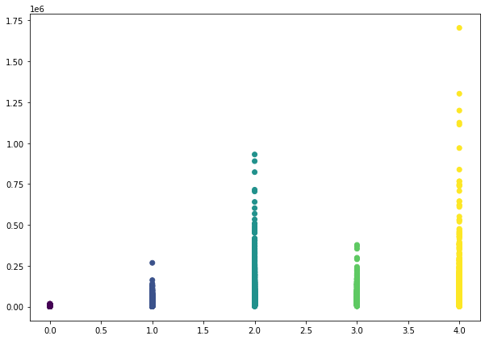

```python
# Plotting Clusters
plt.figure(figsize=(10, 7))
plt.scatter(airline_df1['clustersid'],airline_df1['Balance'], c = clusters.labels_)
```